# How close arms `submitted` and `revised` come to the 2011 targets

The model/target ratio of every calibration target at t = 100, for both arms and both regions; how the 28 September search for `revised` moved its instruments and ratios; whether `revised`’s consumption is half of `submitted`’s (it is not); and why the EU central bank holds no RoW bills while advances are negative.

Author

LEEDS_MODEL — JUST2CE

Published

September 29, 2026

**Written:** 2026-09-29 · **Repo at:** `main` @ `8e07250`, plus the uncommitted `R/plot_calibration_ratios.R` and its outputs. **Reads:** the cached 100-period baselines `output/scenarios/arms/{submitted,revised,adjudicated}/runs/baseline.RDS` (cut 2026-09-23, 2026-09-29 07:35 and 2026-09-29 06:52), through the committed tables `output/calibration/calibration_ratio_cells_20260929.csv`, `consumption_levels_20260929.csv` and `advances_revised_20260929.csv`, which `Rscript R/plot_calibration_ratios.R` writes.

> **Which `revised` this describes.** The calibrated baseline of 28 September, cut 2026-09-29 07:35, before the same day’s restart fix (the money wage is now carried across the spin-up) and change R10. That run is kept as `output/scenarios/arms/revised/runs/baseline_pre_wagecarry_20260929.RDS`. The cached `revised` baseline is now the fixed but **uncalibrated** one; see `qmd/reports/2026-09-29-equation-audit.qmd` §2 for how its ratios moved.

## Figure A — the ratios at t = 100

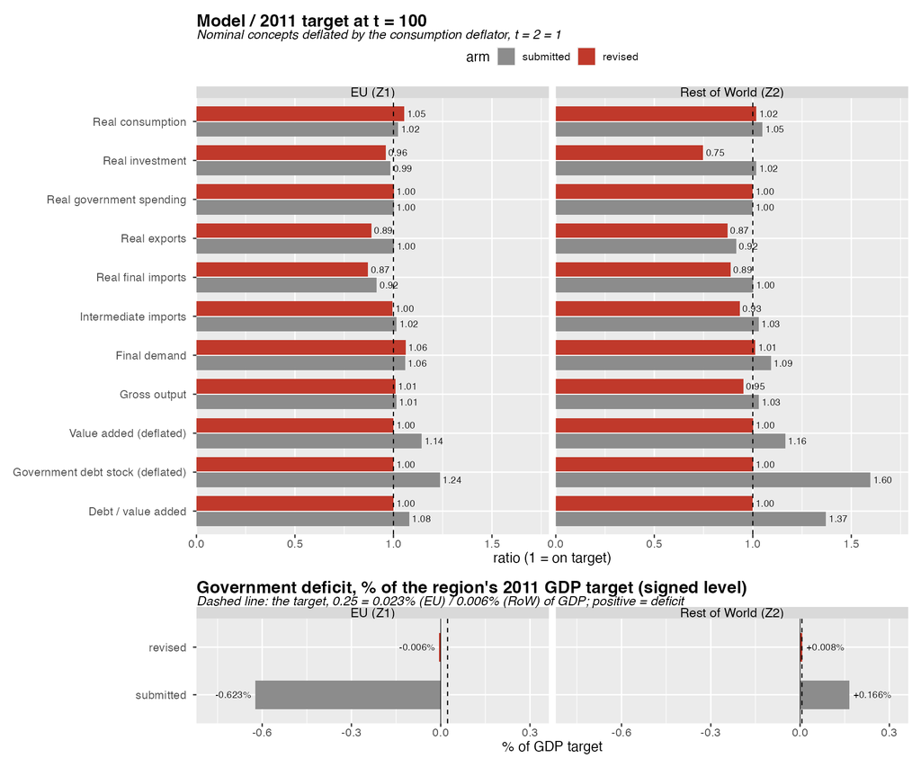

Model / 2011 target at t = 100. Bars: grey `submitted`, red `revised`. The deficit is drawn below it as a signed level in % of the region’s GDP target, because its target (0.25, i.e. 2.5 bn EUR) is 0.023% of EU and 0.006% of RoW GDP, and a ratio to it (−27 for `submitted`) is not interpretable.

Every target cell at t = 100. Units: 10 bn EUR, except debt/value added (a fraction). The deficit’s ratio is shown for completeness only; read it in the figure as a share of GDP.

| region | target concept | 2011 target | submitted | ratio | revised | ratio |
| --- | --- | --- | --- | --- | --- | --- |
| EU | Real consumption | 626.32 | 640.97 | 1.023 | 660.63 | 1.055 |
| EU | Real investment | 196.62 | 193.67 | 0.985 | 188.82 | 0.960 |
| EU | Real government spending | 239.46 | 240.00 | 1.002 | 240.00 | 1.002 |
| EU | Real exports | 102.78 | 103.05 | 1.003 | 91.18 | 0.887 |
| EU | Real final imports | 66.36 | 60.76 | 0.916 | 57.78 | 0.871 |
| EU | Intermediate imports | 123.15 | 125.17 | 1.016 | 122.56 | 0.995 |
| EU | Final demand | 1098.81 | 1163.95 | 1.059 | 1167.24 | 1.062 |
| EU | Gross output | 2153.60 | 2185.73 | 1.015 | 2174.47 | 1.010 |
| EU | Value added (deflated) | 1081.51 | 1237.03 | 1.144 | 1082.06 | 1.001 |
| EU | Government deficit (deflated) | 0.25 | -6.74 | -26.972 | -0.06 | -0.239 |
| EU | Debt stock (deflated) | 876.03 | 1082.62 | 1.236 | 876.48 | 1.001 |
| EU | Debt / value added | 0.81 | 0.88 | 1.080 | 0.81 | 1.000 |
| RoW | Real consumption | 2370.71 | 2488.61 | 1.050 | 2412.12 | 1.017 |
| RoW | Real investment | 908.67 | 925.27 | 1.018 | 679.20 | 0.747 |
| RoW | Real government spending | 675.33 | 675.00 | 1.000 | 675.00 | 1.000 |
| RoW | Real exports | 66.36 | 60.76 | 0.916 | 57.78 | 0.871 |
| RoW | Real final imports | 102.78 | 103.05 | 1.003 | 91.18 | 0.887 |
| RoW | Intermediate imports | 105.85 | 108.95 | 1.029 | 98.84 | 0.934 |
| RoW | Final demand | 3918.29 | 4279.57 | 1.092 | 3968.53 | 1.013 |
| RoW | Gross output | 8424.52 | 8688.28 | 1.031 | 8022.84 | 0.952 |
| RoW | Value added (deflated) | 3935.58 | 4582.34 | 1.164 | 3941.14 | 1.001 |
| RoW | Government deficit (deflated) | 0.25 | 6.54 | 26.155 | 0.32 | 1.292 |
| RoW | Debt stock (deflated) | 3345.25 | 5343.53 | 1.597 | 3349.97 | 1.001 |
| RoW | Debt / value added | 0.85 | 1.17 | 1.372 | 0.85 | 1.000 |

**Reading the table.**

- **Exports and imports mirror each other by construction.** In a two-region model EU real exports are RoW real final imports, which is why the pairs 0.887 / 0.887 and 0.871 / 0.871 repeat across the two regions.
- **The trade shortfall.** In `revised`, trade is 11–13% below its 2011 level in both directions. Two causes are candidates, and neither is separated yet:
  - the Armington gap (hand-off item 2, defect 2);
  - the restart price jump (item 2, defect 3), which leaves Armington reference prices away from the stationary prices.
- **RoW investment at 0.75.** This is a property of `revised`’s capital block (R4, R9: investment is replacement demand K·x plus accumulation). The 09-28 calibration log recorded it as unfixed. The data’s RoW net investment is 203 per period, so the model misses the gross level, not the net one.

## Figure B — the search that calibrated `revised`

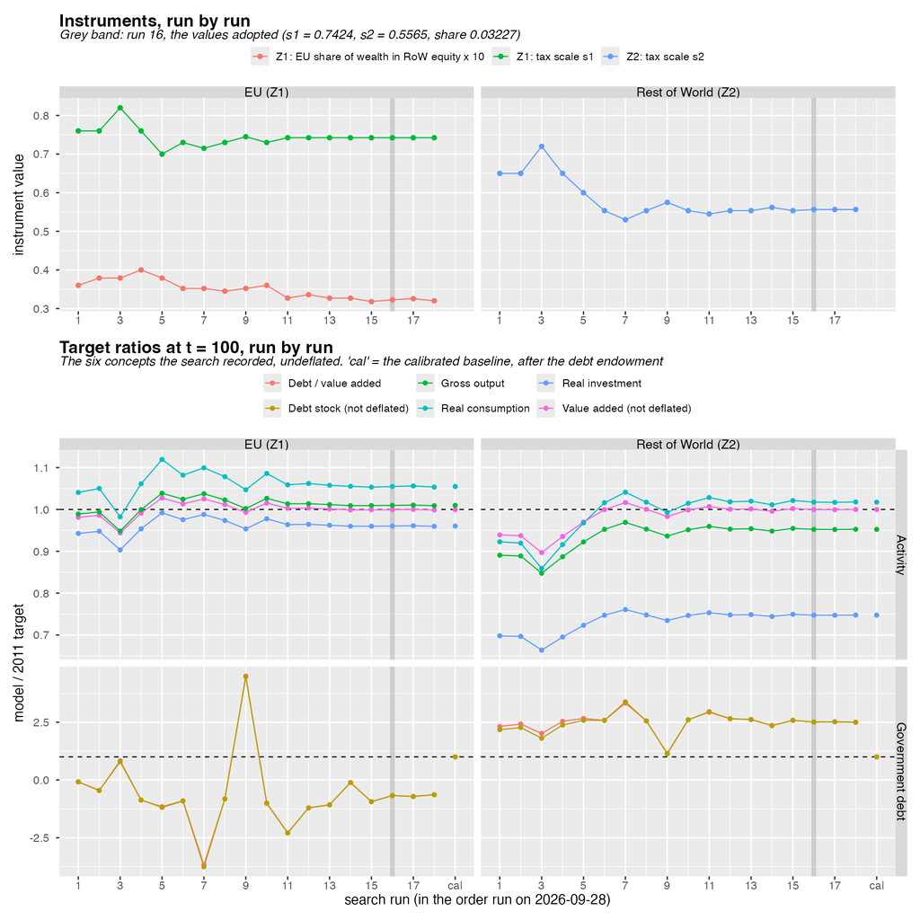

The 28 September joint search (`output/calibration/revised_joint_search_20260928.csv`), 18 runs in the order they were run, faceted by region. Top: the instruments. Bottom: the ratio to target of the six concepts the search recorded, split into activity and government debt. ‘cal’ is the calibrated baseline, cut after the search.

**What the figure shows, stage by stage.** `revised` was calibrated in three stages, and Figure B covers the middle one.

1. **Route A: the current account.** `R/calibrate_revised_cab.R` set the EU share of household wealth in RoW equity (`Z1_lambdaE0_2`, 0.02 in the workbook, not estimated) so that the EU current account is zero. This is what makes the baseline stationary.
   - Output: `output/calibration/revised_cab_search_2026092{8,9}.csv`, 8 + 4 runs. They are not plotted, because they are one-dimensional.
   - Result: 0.03714.
2. **The joint search (Figure B), 18 runs.**
   - **Instruments:**
     - a scale on the EU and RoW tax rates θ_w and θ_c, which sets the level of activity (with a balanced budget, VA = (G + public investment + interest) / net tax rate);
     - the same equity share, re-tuned jointly with the scale.
   - **Adopted:** run 16, with scales 0.7424 (EU) and 0.5565 (RoW) and share 0.03227. From the 29 September commit `442f5f2` these are the workbook’s base values, so a scale of 1 is now the calibrated state.
   - **Debt was not calibrated in this stage.** The debt endowment was 0 throughout, so debt/VA wandered: at run 16 it was −0.55 in the EU and 2.13 in RoW, ratios −0.67 and 2.5.
3. **The debt endowment.** `R/calibrate_revised_debt.R` issued bills to each region’s own central bank at t = 1 of the spin-up: 1466.4 (EU) and −5045.7 (RoW).
   - Why the instrument is an initial condition: under R6 debt and gold share a unit root once the current account is zero, so no flow parameter pins the debt level.
   - Measured on 09-28: the endowment moves debt one for one and leaves value added, consumption and gross output identical to four digits.
   - Figure B confirms it: the ‘cal’ points for the four activity concepts sit exactly on run 16, and debt/VA and the debt stock jump to 1.

**What the search did not record.** Real exports, final imports, intermediate imports, final demand, government spending and the deficit are not in the search file, so their evolution cannot be plotted without re-running the 18 configurations. The recorded levels are also undeflated: `pa` is not in the file. The final ratios of all twelve concepts are in Figure A.

## Is `revised`’s consumption half of `submitted`’s?

**No.** The variable is `Z*_c`, “Total Real Consumption”, in 10 bn EUR at base prices (`data/Variable_Definitions.csv`). Nominal consumption is `pa` × `c`.

Real consumption, its own index from t = 2, the consumption deflator and nominal consumption. `adjudicated` is the reference arm the per-arm reports plot `revised` against.

| arm | region | c at t = 2 | c at t = 100 | c(100) / c(2) | pa at t = 100 | nominal pa·c at t = 100 | 2011 target C |
| --- | --- | --- | --- | --- | --- | --- | --- |
| adjudicated | EU | 270.9 | 650.5 | 2.401 | 1.070 | 696.2 | 626.3 |
| adjudicated | RoW | 971.7 | 2498.4 | 2.571 | 1.067 | 2666.1 | 2370.7 |
| submitted | EU | 270.4 | 641.0 | 2.370 | 1.070 | 686.0 | 626.3 |
| submitted | RoW | 971.1 | 2488.6 | 2.563 | 1.067 | 2655.6 | 2370.7 |
| revised | EU | 725.7 | 660.6 | 0.910 | 1.089 | 719.3 | 626.3 |
| revised | RoW | 2548.2 | 2412.1 | 0.947 | 1.188 | 2865.1 | 2370.7 |

- **In volume at t = 100:**
  - EU: `revised` 660.6 against `submitted` 641.0, +3.1%;
  - RoW: 2,412.1 against 2,488.6, -3.1%.
- **In money:** `revised` is higher in both regions, because its deflator is higher.
  - `pa` is 1.089 (EU) and 1.188 (RoW) against 1.070 and 1.067.
  - The reason is that R1 measures prices of production in money units.
- **So a price-level difference does not hide a volume difference here.** Both arms deflate `c` the same way, and their volumes differ by 3%.
- **Where “half” came from.** The arm report (`qmd/reports/arms/arm-baseline.qmd`, rendered as `output/html/reports/arms/revised.html`) plots `revised` against `adjudicated`, with every series divided by its own value at t = 2.
  - `adjudicated`’s EU consumption runs from 270.9 to 650.5, an index of 2.40, because the fixed-price arms start from the old seed at 43% of target.
  - `revised`’s starts at 725.7 and ends at 660.6, an index of 0.91.
  - On that panel `revised` therefore sits at 0.91 / 2.40 = 0.38 of `adjudicated`.
- **Why `revised` starts high.** Its t = 2 value is itself the restart overshoot: `c` is 701.4 at t = 1, 725.7 at t = 2 and 659.3 at t = 3. That is the same period as the 6–18% price jump at the spin-up restart (hand-off item 2, defect 3). So the index base is the worst possible period for this arm.
- **Recommendation.** The arm reports should plot levels, or index to the target, whenever the two arms start from different initial states. Not changed here; a one-line option in `arm-baseline.qmd`.

## Why is `b_cb_s_Z2` 0 while advances are negative?

The two facts are unrelated.

**`Z1_b_cb_s_Z2` is the EU central bank’s stock of RoW bills.** It is 0 in every period because R6 (G&L OPENFIX) freezes it at its previous value (`model/code/MVP_model_2026.R:1947`, `sim['Z1_b_cb_s_Z2', i] <- sim['Z1_b_cb_s_Z2', i - 1]`), and its t = 1 value is 0.

- The freeze is deliberate. It cuts the RoW treasury → EU central bank → EU treasury interest circuit that compounded at 1 + r_b in the older arms (engine comment at lines 1935–1946).
- The workbook’s `b_cb_d_Z2` is among the 27 labels `revised` never reads (`output/calibration/workbook_usage_revised_20260929.csv`).
- Under OPENFIX the balance of payments settles in gold `or`, not in this stock. That is the closure’s defining choice.

**`a_d` is the banks’ demand for central-bank advances.** Under R7 (`MVP_model_2026.R:683`) banks demand bills as a fixed share of deposits, `b_b = bank_bill_ratio × M_s` (0.1 in both regions), and advances clear the bank balance sheet:

$$A_d = L_s + B_b - M_s .$$

When deposits exceed loans plus bills, A_d is negative. The engine comment at line 187 states the convention: “negative = reserve deposits at the CB”.

**The sign is used consistently everywhere it appears. Checked:**

- **Bank balance sheet.** Assets L + B_b, liabilities M + A. A negative A is an asset of the banks.
- **Central-bank balance sheet.** Supply `a_s` = `a_d` (line 857). The gold-flow identity (line 1957) subtracts Δ`a_s` from ΔH. A fall in A, i.e. a rise in reserves, is therefore a CB liability that adds to its reserve assets, which is the right direction.
- **World gold conservation.** `run.model()`’s consistency check measures it, and it closes (the 09-28 calibration recorded a consistency error of 4.3e-9).

**What is a defect: those reserves earn nothing, and the banks lose money.**

Bank balance sheet and rates in the `revised` baseline (10 bn EUR; rates per period).

| region | variable | t1 | t2 | t100 |
| --- | --- | --- | --- | --- |
| EU | ms | 1549.3657 | 1576.4643 | 1626.7551 |
| EU | ls | 456.9478 | 503.8555 | 504.8164 |
| EU | b_b | 154.9366 | 157.6464 | 162.6755 |
| EU | a_d | -937.4813 | -914.9623 | -959.2632 |
| EU | f_b | -17.0868 | -17.0721 | -17.1350 |
| EU | rm | 0.0226 | 0.0226 | 0.0226 |
| EU | rl | 0.0323 | 0.0323 | 0.0323 |
| EU | rb | 0.0216 | 0.0216 | 0.0216 |
| RoW | ms | 7343.2002 | 7562.5213 | 8644.1715 |
| RoW | ls | 3314.5633 | 3660.8591 | 3580.0033 |
| RoW | b_b | 734.3200 | 756.2521 | 864.4172 |
| RoW | a_d | -3294.3168 | -3145.4101 | -4199.7511 |
| RoW | f_b | -31.4998 | -31.7458 | -47.3380 |
| RoW | rm | 0.0202 | 0.0202 | 0.0202 |
| RoW | rl | 0.0291 | 0.0291 | 0.0291 |
| RoW | rb | 0.0217 | 0.0217 | 0.0217 |
| EU | b_cb_s_Z2 | 0.0000 | 0.0000 | 0.0000 |

- **The balance sheet.** At t = 100 the EU banks hold 1,626.8 of deposits against 504.8 of loans and 162.7 of bills, so 959.3 sits at the central bank.
- **Why they lose money.** Bank profit (line 700) is $f_b = r_l L_f + r_b B_b - r_m M_s + r_h L_h$. It has **no term in A**, so the reserves earn nothing.
  - The deposit rate `rm` is 0.0226, above the bill rate `rb` 0.0216.
  - `f_b` is therefore negative in every period: -17.1 (EU) and -47.3 (RoW).
- **This is consistent accounting of an implausible configuration.** As recalled, not yet checked against the book: in G&L’s ch. 10 bank model reserves are a required fraction of deposits and bills are the residual asset, so banks never sit on 59% of their deposits as idle reserves.
- **Two candidate fixes, for a decision:**
  1. calibrate `bank_bill_ratio` so that A_d ≈ 0, making bills rather than reserves the residual asset. That is roughly 0.69 (EU) and 0.59 (RoW) at the t = 100 balance sheets, since (M − L)/M = 0.69 / 0.59;
  2. pay the policy rate on reserves, adding `ra × A` to both f_b and f_cb.
- **Neither is made here.** Either changes `revised`’s calibrated state and needs a re-cut.

## Found in passing

- **`CLAUDE.md` is out of date on one fact.** It says the gold endowment is “1,500 each, inert”. The workbook holds `Z1_gold_endowment` = 1,500 and `Z2_gold_endowment` = **2,500**, raised on 09-28 because RoW gold ended at −586 (session log 2026-09-29 §6).
- **Search file headers.** The joint-search file’s instrument columns are `d1`, `d2`, `lambda`, `s1` and `s2`. `d1` and `d2` are the debt endowments, 0 in all 18 runs, and `s1`/`s2` are the tax scales. The header does not say this; the script’s comment (`R/calibrate_revised_debt.R:15`) does.

## Reproduce

```bash
Rscript R/plot_calibration_ratios.R    # figures + three CSVs, from the cached baselines (~10 s)
quarto render qmd/reports/2026-09-29-calibration-ratios.qmd --to html --output-dir ../../output/html/reports
```